# Simple Linear Regression - Intro+Formalization

## Exercise 6: Correlation

We can quantify the **linear** relationship between two quantitative variables using a numerical summary known as **correlation** (sometimes known as a “correlation coefficient” or “Pearson’s correlation”). Correlation can range from -1 to 1, where a correlation of 0 indicates that there is *no* linear relationship between the two quantitative variables.

Below is an example of a “Math Box”. You’ll see these occasionally throughout the activities. You are *not* required to memorize, nor will you be assessed on, anything in the math boxes. If you plan on *continuing* with Statistics courses at Macalester (or are interested in the math behind everything!), these math boxes are for you!

**Correlation**

The Pearson correlation coefficient, $r_{x, y}$, of $x$ and $y$ is the (almost) **average** of products of the z-scores of variables $x$ and $y$:

$$r_{x, y} = \frac{\sum z_x z_y}{n - 1}$$

In general, we will want to be able to describe (qualitatively) two aspects of correlation:

1. Strength
- Is the correlation between x and y **strong**, or **weak**, i.e. how closely do the points fit around a line? This has to do with how **dispersed** our point clouds are.
2. Direction
- Is the correlation between x and y **positive** or **negative**, i.e. does y go “up” when x goes “up” (positive), or does y go “down” when x goes “up” (negative)?

Stronger correlations will be *further* from 0 (closer to -1 or 1), and *positive* and *negative* correlations will have the appropriate respective sign (above or below zero).

1. Rather than a smooth trend line, we can force the line we add to our scatterplots to be linear using `geom_smooth(method = 'lm')`, as below:

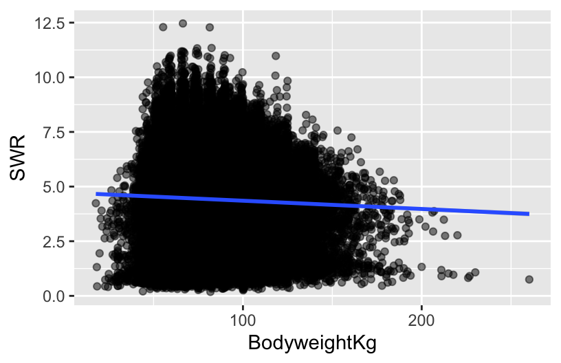

```r
# scatterplot with linear trend line
lifts %>%
  ggplot(aes(x = BodyweightKg, y = SWR)) +
  geom_point(alpha = 0.5) +
  geom_smooth(method = "lm")
```

2. Based on the above scatterplot, how would you describe the correlation between body weight and SWR, in terms of strength and direction?
3. Make a guess as to what *numerical value* the correlation between body weight and SWR will have, based on your response to part (b).

## Exercise 7: Computing correlation in R

We can compute the correlation between body weight and SWR using `summarize` and `cor` functions:

```r
# correlation

# Note: the order in which you put your two quantitative variables into the cor
# function doesn't matter! Try switching them around to confirm this for yourself
# Because of the missing data, we need to include the use = "complete.obs" - otherwise the correlation would be computed as NA
lifts %>%
    summarize(cor(SWR, BodyweightKg, use = "complete.obs"))
## # A tibble: 1 × 1
##   `cor(SWR, BodyweightKg, use = "complete.obs")`
##                                            <dbl>
## 1                                        -0.0392
```

Is the computed correlation close to what you guessed in Exercise 6 part (c)?

## Exercise 8: Limitations of correlation

We previously noted that correlation was a numerical summary of the **linear** relationship between two variables. We’ll now go through some examples of relationships between quantitative variables to demonstrate why it is *incredibly* important to visualize our data *in addition to* just computing numerical summaries!

For this exercise, we’ll be working with the `anscombe` dataset, which is built in to R. To load this dataset into our environment, we run the following code:

```r
# load anscombe data
data("anscombe")
```

The `anscombe` dataset contains four different pairs of quantitative variables:

- `x1`, `y1`
- `x2`, `y2`
- `x3`, `y3`
- `x4`, `y4`

Adapt the code we used in Exercise 7 to compute the correlation between each of these four pairs of variables, below:

```r
# correlation between x1, y1

# correlation between x2, y2

# correlation between x3, y3

# correlation between x4, y4
```

1. What do you notice about each of these correlations (if the answer to this isn’t obvious, double-check your code)?
2. Describe these correlations in terms of strength and direction, using only the numerical summary to assist you in your description.
3. Draw an example on the white board or at your tables of what you **think** the point clouds for these pairs of variables might look like. There are only 11 observations, so you can draw all 11 points if you’d like!
4. Adapt the code for scatterplots given previously in this activity to make *four* distinct scatterplots for each pair of quantitative variables in the `anscombe` dataset. You do not need to add a smooth trend line or a linear trend line to these plots.

```r
# scatterplot: x1, y1

# scatterplot: x2, y2

# scatterplot: x3, y3

# scatterplot: x4, y4
```

5. Based on the correlations you calculated and scatterplots you made, what is the *message* of this last exercise as it relates to the limits of correlation?

## Reflection

Much of statistics is about making (hopefully) reasonable assumptions in attempt to summarize observed relationships in data. Today we started considering assumptions of *linear* relationships between quantitative variables.

Review the learning objectives at the top of this file and today’s activity. How do you imagine assumptions of linearity might be useful in terms of quantifying relationships between quantitative variables? How do you imagine these assumptions could sometimes fall short, or even be unethical in certain cases?

> **Response:** Put your response here.

# Discovery - Intuition for **Least Squares**

## Exercise 9: Lines of best fit

In this activity, we’ve learned how to fit straight lines to data, to help us visualize the relationship between two quantitative variables. So far, `ggplot` has chosen the line for us. How does it know which line is “best”, and what does “best” even mean?

For this exercise, we’ll consider the relationship between `x1` and `y1` in the `anscombe` dataset. Run the following code, which creates a scatterplot with a fitted line to our data using the function `geom_abline`:

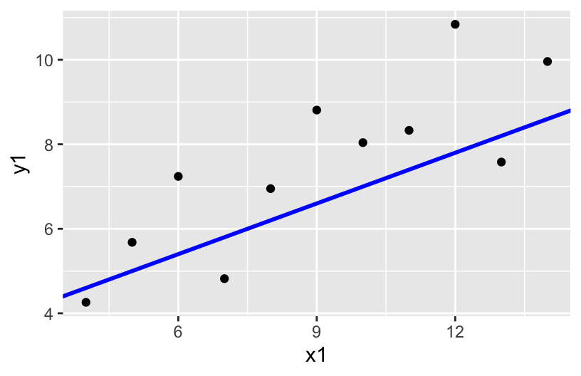

```r
# scatterplot with a fitted line, whose slope is 0.4 and intercept is 3
anscombe %>%
  ggplot(aes(x = x1, y = y1)) +
  geom_point() +
  geom_abline(slope = 0.4, intercept = 3, col = "blue", size = 1)
```

Describe the line that you see. Do you think the line is “good”? What are you using to define “good”?

Some things to think about:

- How many points are **above** the line?
- How many points are **below** the line?
- Are the **distances** of the points above and below the line roughly similar, or is there meaningful difference?

Now we’ll add *another* line to our plot. Which line do you think is *better* suited for this data? Why? Be specific!

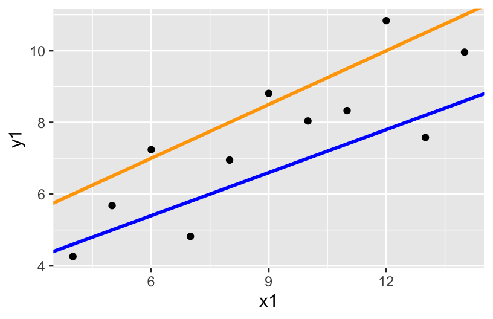

```r
# scatterplot with a fitted line, whose slope is 0.4 and intercept is 3
anscombe %>%
  ggplot(aes(x = x1, y = y1)) +
  geom_point() +
  geom_abline(slope = 0.4, intercept = 3, col = "blue", size = 1) +
  geom_abline(slope = 0.5, intercept = 4, col = "orange", size = 1)
```

It’s usually quite simple to note when a line is *bad*, but more difficult to quantify when a line is a *good* fit for our data. Consider the following line:

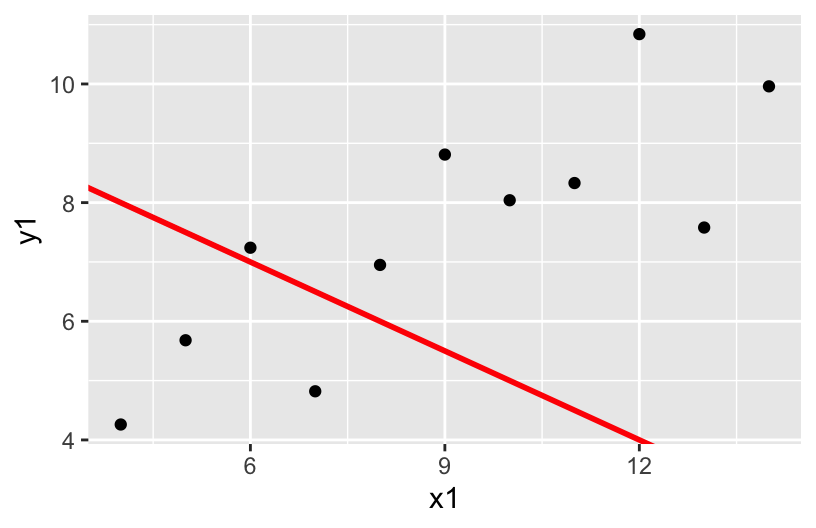

```r
# scatterplot with a fitted line, whose slope is 0.4 and intercept is 3
anscombe %>%
  ggplot(aes(x = x1, y = y1)) +
  geom_point() +
  geom_abline(slope = -0.5, intercept = 10, col = "red", size = 1)
```

In the next activity, we’ll formalize the **principle of least squares**, which will give us one particular definition of a *line of best fit* that is commonly used in statistics! We’ll take advantage of the vertical distances between each point and the fitted line (**residuals**), which will help us define (mathematically) a line that best fits our data:

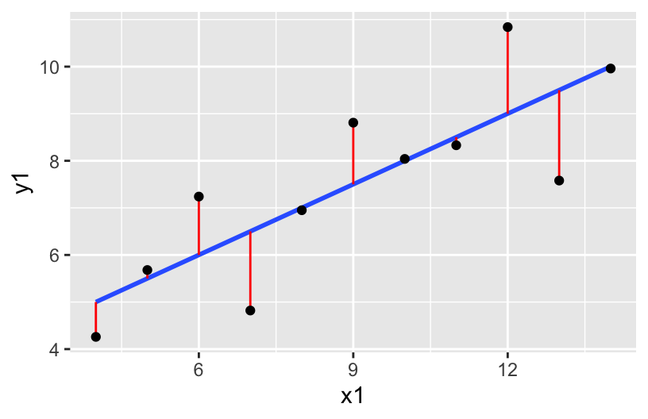

```r
library(broom)
anscombe %>%
  lm(y1 ~ x1, data = .) %>%
  augment() %>%
  ggplot(aes(x = x1, y = y1)) +
  geom_smooth(method = "lm", se = FALSE) +
  geom_segment(aes(xend = x1, yend = .fitted), col = "red") +
  geom_point()
```

# Additional Practice

## Exercise 10: Correlation and **extreme** values

In this exercise, we’ll explore how correlation changes with the addition of **extreme** values, or observations. We’ll begin by generating a *toy* dataset called `dat` with two quantitative variables, `x` and `y`. Run the code below to create the dataset.

**while not required, recall that you can look up function documentation in R using the `?` in front of a function name to figure out what that function is doing!**

```r
# create a toy dataset
set.seed(1234)
x <- rnorm(100, mean = 5, sd = 2)
y <- -3 * x + rnorm(100, sd = 4)
dat <- data.frame(x = x, y = y)
```

1. Make a scatterplot of `x` vs. `y`.

```r
# scatterplot
```

2. Based on your scatterplot, describe the correlation between `x` and `y` in terms of strength and direction.
3. Guess the correlation (the numerical value) between `x` and `y`.
4. Compute the correlation between `x` and `y`. Was your guess from part (c) close?

```r
# correlation
```

5. Suppose we observe an additional observation with `x = 15` and `y = -45`. We can create a new data frame, `dat_new1`, that contains this observation in addition to the original ones as follows:

```r
# creating dat_new1
x1 <- c(x, 15)
y1 <- c(y, -45)
dat_new1 <- data.frame(x = x1, y = y1)
```

6. Make a scatterplot of `x` vs. `y` for this new data frame, and compute the correlation between `x` and `y`. Did your correlation change very much with the addition of this observation? Hypothesize why or why not.

```r
# scatterplot

# correlation
```

```r
# creating dat_new1
x2 <- c(x, 15)
y2 <- c(y, 45)
dat_new2 <- data.frame(x = x2, y = y2)
```

8. Make a scatterplot of `x` vs. `y` for this new data frame, and compute the correlation between `x` and `y`. Did your correlation change very much with the addition of *this* observation? Hypothesize why or why not.

```r
# scatterplot

# correlation
```

1. What do you think the takeaway message is of this exercise?
10. **Challenge** Add linear trend lines to your scatterplots from parts (f) and (h). Does this give you any additional insight into why the correlations may have changed in different ways with the addition of a new observation?

# Solutions

## Exercise 1: Get to know the data

```r
dim(bikes)
## [1] 731  15

head(bikes)
## # A tibble: 6 × 15
##   date       season  year month day_of_week weekend holiday temp_actual
##   <date>     <chr>  <dbl> <chr> <chr>       <lgl>   <chr>         <dbl>
## 1 2011-01-01 winter  2011 Jan   Sat         TRUE    no             57.4
## 2 2011-01-02 winter  2011 Jan   Sun         TRUE    no             58.8
## 3 2011-01-03 winter  2011 Jan   Mon         FALSE   no             46.5
## 4 2011-01-04 winter  2011 Jan   Tue         FALSE   no             46.8
## 5 2011-01-05 winter  2011 Jan   Wed         FALSE   no             48.7
## 6 2011-01-06 winter  2011 Jan   Thu         FALSE   no             47.1
## # ℹ 7 more variables: temp_feel <dbl>, humidity <dbl>, windspeed <dbl>,
## #   weather_cat <chr>, riders_casual <dbl>, riders_registered <dbl>,
## #   riders_total <dbl>
```

1. A case represents a day of the year.
2. We have 15 variables broadly concerning weather, day of week information, whether the day is a holiday.
3. Lots of answers are reasonable here! When and where seem to be particularly relevant because this is for a rideshare based in Washington DC with data from 2011-2012. Ridership likely changes a lot from city to city and over time.

## Exercise 2: Get to know the outcome/response variable

The distribution of the `riders_registered` variable looks fairly symmetric. On average there are about 3600 registered riders per day (mean = 3656, median = 3662). On any given day, the number of registered riders is about 1560 from the mean. There seem to be a small number of low outliers (minimum ridership was 20).

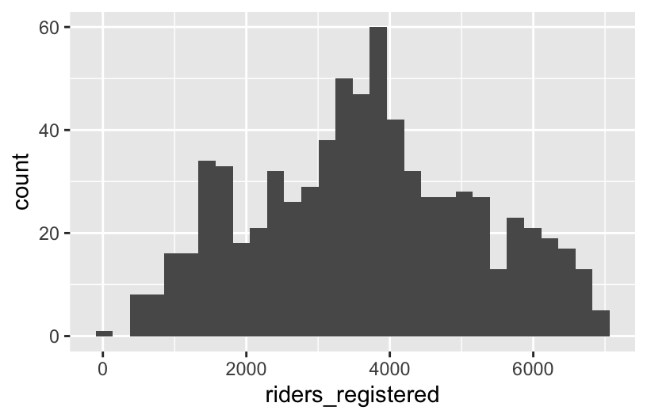

```r
ggplot(bikes, aes(x = riders_registered)) +
    geom_histogram()
```

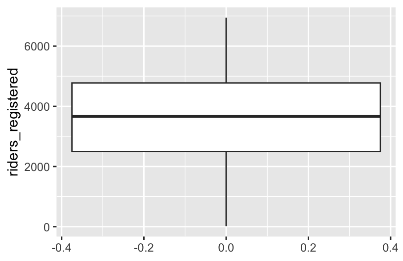

```r
ggplot(bikes, aes(y = riders_registered)) +
    geom_boxplot()
```

```r
summary(bikes$riders_registered)
##    Min. 1st Qu.  Median    Mean 3rd Qu.    Max.
##      20    2497    3662    3656    4776    6946

bikes %>%
    summarize(sd(riders_registered))
## # A tibble: 1 × 1
##   `sd(riders_registered)`
##                     <dbl>
## 1                   1560.
```

## Exercise 3: Explore the relationship between ridership and temperature

We’d like to understand how daily ridership among registered users relates with the temperature that it feels like that day (`temp_feel`).

1. Scatterplot (outcome and predictor are both quantitative)

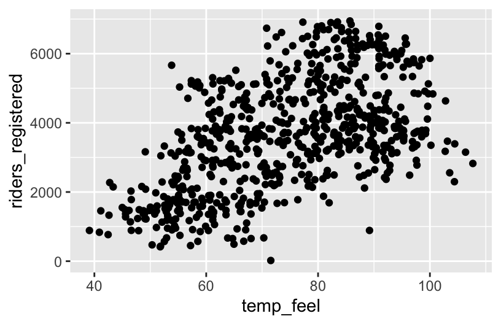

```r
ggplot(bikes, aes(x = temp_feel, y = riders_registered)) +
    geom_point()
```

3. If we only displayed the red line of best fit on the plot, we might miss the slight downward trend at the highest temperatures that we can see more clearly with the blue curve of best fit. A linear model is not appropriate if fit to the whole range of the data, but there does seem to be a linear relationship between ridership and temperature below 80 degrees Fahrenheit.

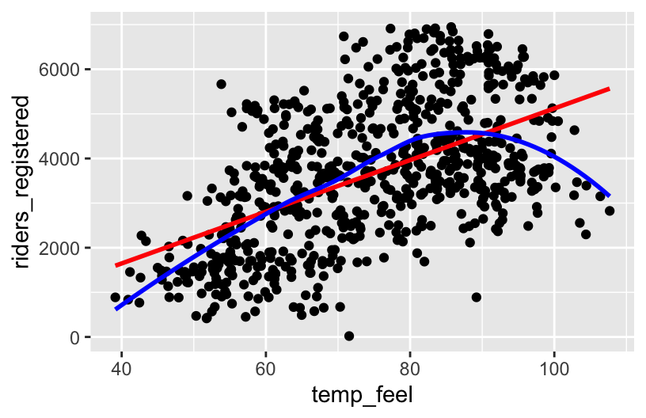

```r
# Add a red straight line of best fit and a blue curve of best fit
ggplot(bikes, aes(x = temp_feel, y = riders_registered)) +
    geom_point() +
    geom_smooth(method = "lm", color = "red", se = FALSE) +
    geom_smooth(color = "blue", se = FALSE)
```

## Exercise 4: Filtering our data

```r
# The %>% is called a "pipe" and feeds what comes before it
# into what comes after (bikes data is "fed into" the filter() function)
bikes_sub <- bikes %>%
    filter(temp_feel < 80)
```

## Exercise 5: Model fitting and coefficient interpretation

Let’s fit a simple linear regression model and examine the results. Step through code chunk slowly, and make note of new code.

```r
# Construct and save the model as bike_mod
# What's the purpose of "riders_registered ~ temp_feel"?
# What's the purpose of "data = bikes_sub"?
bike_mod <- lm(riders_registered ~ temp_feel, data = bikes_sub)
```

```r
# A long summary of the model stored in bike_mod
summary(bike_mod)
##
## Call:
## lm(formula = riders_registered ~ temp_feel, data = bikes_sub)
##
## Residuals:
##     Min      1Q  Median      3Q     Max
## -3681.8  -928.3   -98.6   904.9  3496.7
##
## Coefficients:
##              Estimate Std. Error t value Pr(>|t|)
## (Intercept) -2486.412    421.379  -5.901 7.37e-09 ***
## temp_feel      86.493      6.464  13.380  < 2e-16 ***
## ---
## Signif. codes:  0 '***' 0.001 '**' 0.01 '*' 0.05 '.' 0.1 ' ' 1
##
## Residual standard error: 1267 on 428 degrees of freedom
## Multiple R-squared:  0.2949, Adjusted R-squared:  0.2933
## F-statistic:   179 on 1 and 428 DF,  p-value: < 2.2e-16
```

```r
# A simplified model summary
coef(summary(bike_mod))
##                Estimate Std. Error   t value     Pr(>|t|)
## (Intercept) -2486.41180 421.379174 -5.900652 7.368345e-09
## temp_feel      86.49251   6.464247 13.380135 2.349753e-34
```

## Exercise 6: Predictions and residuals

On August 17, 2012, the `temp_feel` was 53.816 degrees and there were 5665 riders. We can get data for this day using the `filter()` and `select()` `dplyr` functions. Note, but don’t worry about the syntax – we haven’t learned this yet:

```r
bikes_sub %>%
    filter(date == "2012-08-17") %>%
    select(riders_registered, temp_feel)
## # A tibble: 1 × 2
##   riders_registered temp_feel
##               <dbl>     <dbl>
## 1              5665      53.8
```

1. *More* riders than expected – the point is far above the trend line
2. -2486.41180 + 86.49251 * 53.816 = 2168.269
3. We get the same result with `predict()`:

```r
# What is the purpose of newdata = ___???
predict(bike_mod, newdata = data.frame(temp_feel = 53.816))
##        1
## 2168.269
```

4. residual = 5665 - 2168.269 = 3496.731. On August 17, 2012, there were 3496.731 more riders than would be expected from our model.
5. - Positive residuals are above the trend line—we under-estimate ridership.
   - Negative residuals are below the trend line—we over-estimate ridership.
6. On an 85 degree day, we would predict 4865.452 riders. Even though we can compute this prediction, it’s not a good idea because of extrapolation–the data that we used to fit our model was filtered to days less than 80 degrees.

```r
-2486.41180 + 86.49251 * 85
## [1] 4865.452
predict(bike_mod, newdata = data.frame(temp_feel = 85))
##        1
## 4865.451
```

## Exercise 7: Changing temperature units (CHALLENGE)

If we had measured temperature in degrees Celsius rather than degrees Fahrenheit, both the intercept and slope should change. The intercept would now represent 0 degrees Celsius (32 degrees Fahrenheit) and a one unit change in temperature is now 1 degree Celsius (1.8 degrees Fahrenheit).

## Exercise 8: Ridership and windspeed

Let’s pull together everything that you’ve practiced in the preceding exercises to investigate the relationship between `riders_registered` and `windspeed`. Go back to using the `bikes` dataset (instead of `bikes_sub`) because we no longer need to only keep days less than 80 degrees.

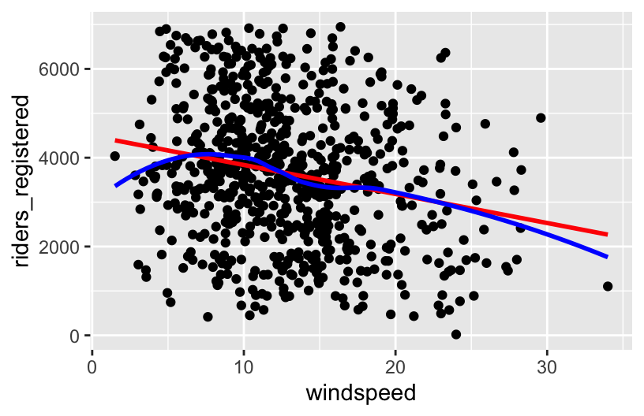

```r
# Construct and interpret a visualization of this relationship
# Include a representation of the relationship trend
ggplot(bikes, aes(x = windspeed, y = riders_registered)) +
    geom_point() +
    geom_smooth(method = "lm", color = "red", se = FALSE) +
    geom_smooth(color = "blue", se = FALSE)
```

```r
# Use lm to construct a model of riders_registered vs windspeed
# Save this as bike_mod2
bike_mod2 <- lm(riders_registered ~ windspeed, data = bikes)

# Get a short summary of this model
coef(summary(bike_mod2))
##               Estimate Std. Error   t value      Pr(>|t|)
## (Intercept) 4490.09761  149.65992 30.002005 2.023179e-129
## windspeed    -65.34145   10.86299 -6.015053  2.844453e-09
```

1. There’s a weak, negative relationship – ridership tends to be smaller on windier days.
2. E[riders_registered | windspeed] = 4490.09761 - 65.34145 windspeed
3. - **Intercept:** On days with no wind, we’d expect around 4490 riders. (0 is a little below the minimum of the observed data, but not by much! So extrapolation in interpreting the intercept isn’t a huge concern.)
   - **Slope:** Every 1mph increase in windspeed is associated with a ridership decrease of 65 riders on average.
4. See the code below to predict ridership on August 17, 2012 and calculate the corresponding residual. Note that this residual is smaller than the residual from the temperature model (that residual was 3496.731). This indicates that August 17 was more of an outlier in ridership given the temperature than the windspeed.

```r
bikes %>%
    filter(date == "2012-08-17") %>%
    select(riders_registered, windspeed)
## # A tibble: 1 × 2
##   riders_registered windspeed
##               <dbl>     <dbl>
## 1              5665      15.5

# prediction
4490.09761 - 65.34145 * 15.50072
## [1] 3477.258

# residual
5665 - 3477.258
## [1] 2187.742
```

## Exercise 9: Data drills (`filter`, `select`, `summarize`)

This exercise is designed to help you keep building your `dplyr` skills. These skills are important to data cleaning and digging, which in turn is important to really making meaning of our data. We’ll work with a simpler set of 10 data points:

```r
new_bikes <- bikes %>%
    select(date, temp_feel, humidity, riders_registered, day_of_week) %>%
    head(10)
```

### Verb 1: `summarize`

`summarize()` calculates numerical summaries of variables (columns).

```r
new_bikes %>%
    summarize(mean(temp_feel), mean(humidity))
## # A tibble: 1 × 2
##   `mean(temp_feel)` `mean(humidity)`
##               <dbl>            <dbl>
## 1              52.0            0.544
```

### Verb 2: `select`

`select()` selects variables (columns).

```r
new_bikes %>%
    select(date, temp_feel)
## # A tibble: 10 × 2
##    date       temp_feel
##    <date>         <dbl>
##  1 2011-01-01      64.7
##  2 2011-01-02      63.8
##  3 2011-01-03      49.0
##  4 2011-01-04      51.1
##  5 2011-01-05      52.6
##  6 2011-01-06      53.0
##  7 2011-01-07      50.8
##  8 2011-01-08      46.6
##  9 2011-01-09      42.5
## 10 2011-01-10      45.6
```

```r
new_bikes %>%
    select(-date, -temp_feel)
## # A tibble: 10 × 3
##    humidity riders_registered day_of_week
##       <dbl>             <dbl> <chr>
##  1    0.806               654 Sat
##  2    0.696               670 Sun
##  3    0.437              1229 Mon
##  4    0.590              1454 Tue
##  5    0.437              1518 Wed
##  6    0.518              1518 Thu
##  7    0.499              1362 Fri
##  8    0.536               891 Sat
##  9    0.434               768 Sun
## 10    0.483              1280 Mon
```

### Verb 3: `filter`

`filter()` keeps only days (rows) that meet the given condition(s).

```r
new_bikes %>%
    filter(riders_registered > 850)
## # A tibble: 7 × 5
##   date       temp_feel humidity riders_registered day_of_week
##   <date>         <dbl>    <dbl>             <dbl> <chr>
## 1 2011-01-03      49.0    0.437              1229 Mon
## 2 2011-01-04      51.1    0.590              1454 Tue
## 3 2011-01-05      52.6    0.437              1518 Wed
## 4 2011-01-06      53.0    0.518              1518 Thu
## 5 2011-01-07      50.8    0.499              1362 Fri
## 6 2011-01-08      46.6    0.536               891 Sat
## 7 2011-01-10      45.6    0.483              1280 Mon
```

```r
new_bikes %>%
    filter(day_of_week == "Sat")
## # A tibble: 2 × 5
##   date       temp_feel humidity riders_registered day_of_week
##   <date>         <dbl>    <dbl>             <dbl> <chr>
## 1 2011-01-01      64.7    0.806               654 Sat
## 2 2011-01-08      46.6    0.536               891 Sat
```

```r
new_bikes %>%
    filter(riders_registered > 850, day_of_week == "Sat")
## # A tibble: 1 × 5
##   date       temp_feel humidity riders_registered day_of_week
##   <date>         <dbl>    <dbl>             <dbl> <chr>
## 1 2011-01-08      46.6    0.536               891 Sat
```

## Exercise 10: Your turn

Use `dplyr` verbs to complete each task below.

```r
# Keep only information about the humidity and day of week
new_bikes %>%
    select(humidity, day_of_week)
## # A tibble: 10 × 2
##    humidity day_of_week
##       <dbl> <chr>
##  1    0.806 Sat
##  2    0.696 Sun
##  3    0.437 Mon
##  4    0.590 Tue
##  5    0.437 Wed
##  6    0.518 Thu
##  7    0.499 Fri
##  8    0.536 Sat
##  9    0.434 Sun
## 10    0.483 Mon

# Keep only information about the humidity and day of week using a different approach
new_bikes %>%
    select(-date, -temp_feel, -riders_registered)
## # A tibble: 10 × 2
##    humidity day_of_week
##       <dbl> <chr>
##  1    0.806 Sat
##  2    0.696 Sun
##  3    0.437 Mon
##  4    0.590 Tue
##  5    0.437 Wed
##  6    0.518 Thu
##  7    0.499 Fri
##  8    0.536 Sat
##  9    0.434 Sun
## 10    0.483 Mon

# Keep only information for Sundays
new_bikes %>%
    filter(day_of_week == "Sun")
## # A tibble: 2 × 5
##   date       temp_feel humidity riders_registered day_of_week
##   <date>         <dbl>    <dbl>             <dbl> <chr>
## 1 2011-01-02      63.8    0.696               670 Sun
## 2 2011-01-09      42.5    0.434               768 Sun

# Keep only information for Sundays with temperatures below 50
new_bikes %>%
    filter(day_of_week == "Sun", temp_feel < 50)
## # A tibble: 1 × 5
##   date       temp_feel humidity riders_registered day_of_week
##   <date>         <dbl>    <dbl>             <dbl> <chr>
## 1 2011-01-09      42.5    0.434               768 Sun

# Calculate the maximum and minimum temperatures
new_bikes %>%
    summarize(min(temp_feel), max(temp_feel))
## # A tibble: 1 × 2
##   `min(temp_feel)` `max(temp_feel)`
##              <dbl>            <dbl>
## 1             42.5             64.7
```

# Solution: Additional Practice

[output not shown]

## Exercise 1: Get to know the data

1. Use an appropriate function to look at the first few rows of the data.

```r
head(lifts)
## # A tibble: 6 × 21
##   Name        Sex   Event Equipment   Age BodyweightKg Best3SquatKg Best3BenchKg
##   <chr>       <chr> <chr> <chr>     <dbl>        <dbl>        <dbl>        <dbl>
## 1 Natalya Po… F     D     Raw        37           58.4          NA          NA
## 2 Fatima Rod… F     SBD   Single-p…  NA           74.8          NA          NA
## 3 Josh Kelley M     SBD   Single-p…  NA           72.4         147.         97.5
## 4 Timothy Ca… M     D     Raw        16           72.9          NA          NA
## 5 M Moynihan  M     B     Raw        NA           67.5          NA         100
## 6 Lucas Wegr… M     B     Raw        23.5        103.           NA         188.
## # ℹ 13 more variables: Best3DeadliftKg <dbl>, TotalKg <dbl>, Place <chr>,
## #   Dots <dbl>, Wilks <dbl>, Glossbrenner <dbl>, Goodlift <dbl>, Tested <chr>,
## #   Country <chr>, State <chr>, Date <date>, MeetCountry <chr>, MeetState <chr>
```

2. Create a new code chunk, and use an appropriate function to learn how much data we have (in terms of cases and variables).

```r
dim(lifts)
## [1] 100000     21
```

3. A case represents an individual lifter at a single weightlifting competition.
4. It looks like some meets may be missing if they weren’t detected by the web scraper used by the maintainers of the Open Powerlifting database. They don’t describe in detail the process used for transferring PDFs of results to their database, so it’s unclear what errors in transcription might have resulted. Still, it’s worth taking a moment to appreciate the labor they put into making these results available for passionate powerlifters to explore.

## Exercise 2: Mutating our data

Strength-to-weight ratio (SWR) is defined as `TotalKg`/`BodyweightKg`. We can use the `mutate()` function from the `dplyr` package to create a new variable in our dataframe for `SWR` using the following code:

```r
lifts <- lifts %>%
    mutate(SWR = TotalKg / BodyweightKg)
```

Adapt the example above to create a new variable called `SWR`, where SWR is defined as `TotalKg`/`BodyweightKg`.

## Exercise 3: Get to know the outcome/response variable

Let’s get acquainted with the `SWR` variable.

- Construct an appropriate plot to visualize the distribution of this variable, and compute appropriate numerical summaries.

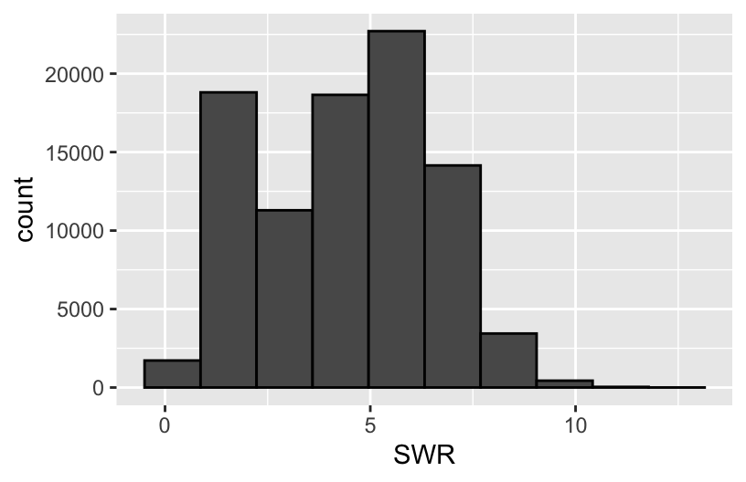

```r
lifts %>%
  ggplot(aes(SWR)) +
  geom_histogram(bins = 10, col = "black")
```

```r
lifts %>% summarize(mean(SWR, na.rm = TRUE), min(SWR, na.rm = TRUE), max(SWR, na.rm = TRUE), sd(SWR, na.rm = TRUE))
## # A tibble: 1 × 4
##   `mean(SWR, na.rm = TRUE)` `min(SWR, na.rm = TRUE)` `max(SWR, na.rm = TRUE)`
##                       <dbl>                    <dbl>                    <dbl>
## 1                      4.42                    0.183                     12.5
## # ℹ 1 more variable: `sd(SWR, na.rm = TRUE)` <dbl>
```

- Write a good paragraph interpreting the plot and numerical summaries.

## Exercise 4: Data visualization - two quantitative variables

We’d like to visualize the relationship between body weight and the strength-to-weight ratio. A **scatterplot** (or informally, a “point cloud”) allows us to do this! The code below creates a scatterplot of body weight vs. SWR using `ggplot()`.

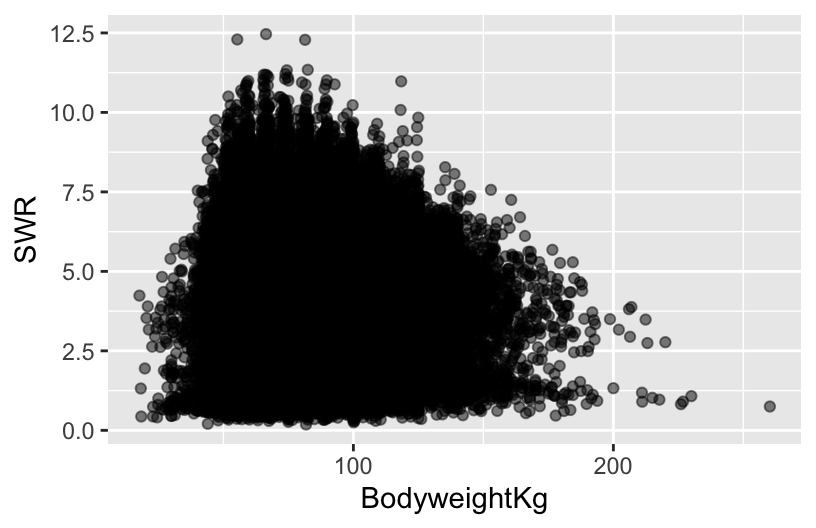

```r
# scatterplot

# The alpha = 0.5 in geom_point() adds transparency to the points
# to make them easier to see. You can make this smaller for more transparency
lifts %>%
  ggplot(aes(x = BodyweightKg, y = SWR)) +
  geom_point(alpha = 0.5)
```

a & b. In our plot aesthetics, we now have *two* variables listed (an “x” and a “y”) as opposed to just a single variable. The “geom” for a scatterplot is `geom_point`. Otherwise, the code structure remains very similar!

3. In general, it seems as though higher body weights are associated with lower SWRs. Once body weight (in kg) is greater than 50, the relationship between body weight and SWR appears to be weakly negative, and roughly linear. The points are very dispersed, indicating that there is a good amount of variation in this relationship (hence the term “weak”).

## Exercise 5: Scatterplots - patterns in point clouds

Sometimes, it can be easier to see a pattern in a point cloud by adding a **smoothing** line to our scatterplots. The code below adapts the code in Exercise 4 to do this:

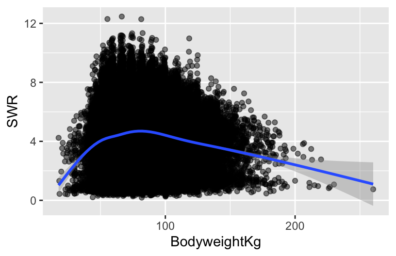

```r
# scatterplot with smoothing line
lifts %>%
  ggplot(aes(x = BodyweightKg, y = SWR)) +
  geom_point(alpha = 0.5) +
  geom_smooth()
```

1. This doesn’t change my answer much (but it may have changed yours, and that’s okay!). It does appear as though there is a weakly negative relationship between body weight and SWR, particularly once body weight is above a certain value.
2. I would say that yes, a linear relationship here seems reasonable! Even though there is some curvature in the smoothed trend line early on, that is based on **very few** data points. Those data points with low body weights aren’t enough to convince me that the relationship couldn’t be roughly linear between body weight and SWR.

## Exercise 6: Correlation

2. I would describe the correlation between body weight and SWR as weak and negative.
3. I’ll guess -0.1, since the line is negative, and the points are very dispersed around the line!

## Exercise 7: Computing correlation in R

```r
# correlation

# Note: the order in which you put your two quantitative variables into the cor
# function doesn't matter! Try switching them around to confirm this for yourself
# Because of the missing data, we need to include the use = "complete.obs" - otherwise the correlation would be computed as NA
lifts %>%
    summarize(cor(SWR, BodyweightKg, use = "complete.obs"))
## # A tibble: 1 × 1
##   `cor(SWR, BodyweightKg, use = "complete.obs")`
##                                            <dbl>
## 1                                        -0.0392
```

So close to our guess!

## Exercise 8: Limitations of correlation

```r
# correlation between x1, y1
anscombe %>% summarize(cor(x1, y1))
##   cor(x1, y1)
## 1   0.8164205

# correlation between x2, y2
anscombe %>% summarize(cor(x2, y2))
##   cor(x2, y2)
## 1   0.8162365

# correlation between x3, y3
anscombe %>% summarize(cor(x3, y3))
##   cor(x3, y3)
## 1   0.8162867

# correlation between x4, y4
anscombe %>% summarize(cor(x4, y4))
##   cor(x4, y4)
## 1   0.8165214
```

1. Each of these correlations are nearly the same!
2. Each of these correlations is relatively strong, and positive, since 0.8 is positive and closer to 1 than 0.

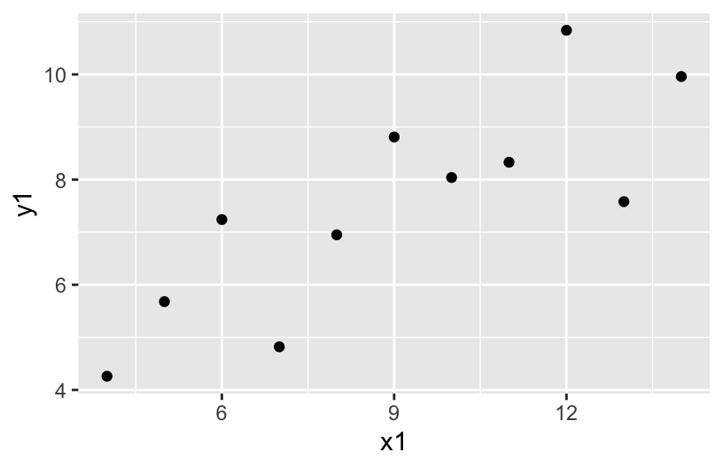

```r
# scatterplot: x1, y1
anscombe %>%
  ggplot(aes(x = x1, y = y1)) +
  geom_point()
```

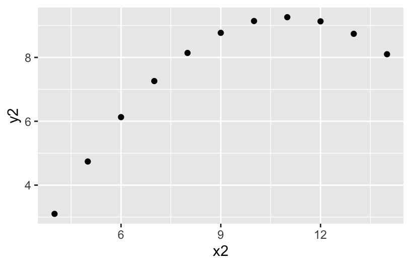

```r
# scatterplot: x2, y2
anscombe %>%
  ggplot(aes(x = x2, y = y2)) +
  geom_point()
```

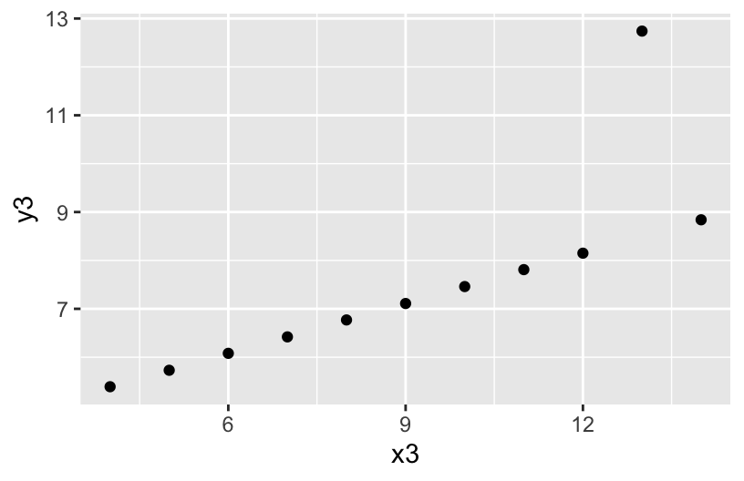

```r
# scatterplot: x3, y3
anscombe %>%
  ggplot(aes(x = x3, y = y3)) +
  geom_point()
```

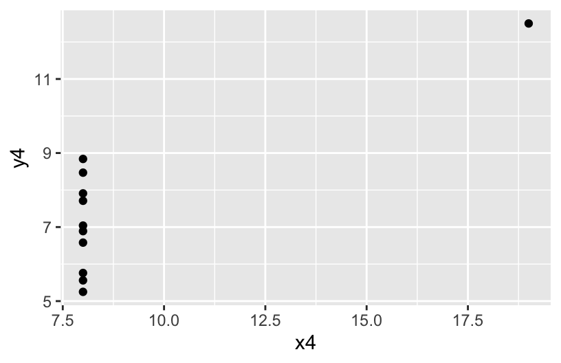

```r
# scatterplot: x4, y4
anscombe %>%
  ggplot(aes(x = x4, y = y4)) +
  geom_point()
```

5. The message of this exercise is that data visualization is important *in addition* to numerical summaries! Many different sets of points can have nearly the same correlation, but display very different patterns in point clouds upon closer inspection. Reporting correlation alone is not enough to summarize the relationship between two quantitative variables, and should be accompanied by a scatter plot!

## Exercise 10: Correlation and **extreme** values

```r
# create a toy dataset
set.seed(1234)
x <- rnorm(100, mean = 5, sd = 2)
y <- -3 * x + rnorm(100, sd = 4)
dat <- data.frame(x = x, y = y)
```

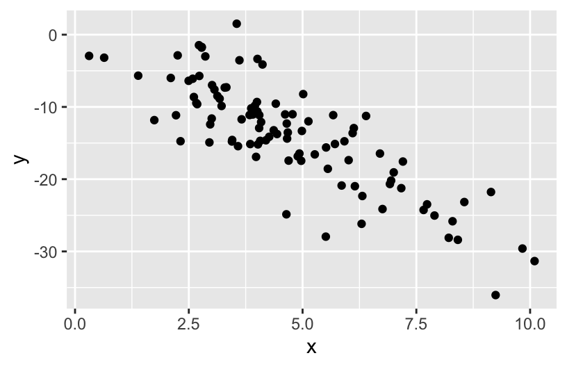

```r
# scatterplot
dat %>%
  ggplot(aes(x = x, y = y)) +
  geom_point()
```

2. The correlation between x and y is moderately strong and negative.
3. I’ll guess -0.6, since the relationship is negative and is sort of in-between weak and strong.

```r
# correlation
dat %>% summarize(cor(x, y))
##    cor(x, y)
## 1 -0.8295483
```

```r
# creating dat_new1
x1 <- c(x, 15)
y1 <- c(y, -45)
dat_new1 <- data.frame(x = x1, y = y1)
```

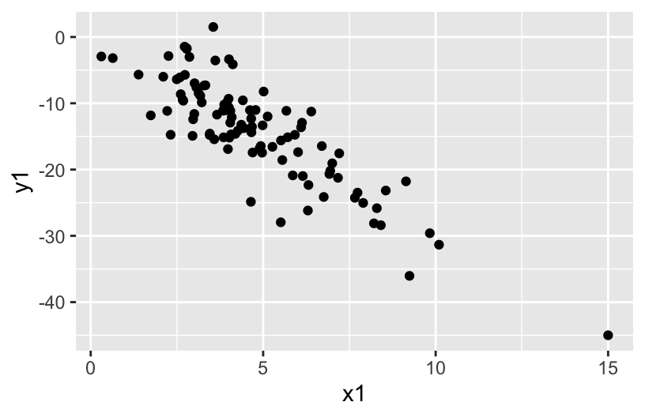

```r
# scatterplot
dat_new1 %>%
  ggplot(aes(x1, y1)) +
  geom_point()
```

```r
# correlation
dat %>% summarize(cor(x1, y1))
##   cor(x1, y1)
## 1  -0.8573567
```

Our correlation stayed roughly the same with the addition of this new point!

```r
# creating dat_new1
x2 <- c(x, 15)
y2 <- c(y, 45)
dat_new2 <- data.frame(x = x2, y = y2)
```

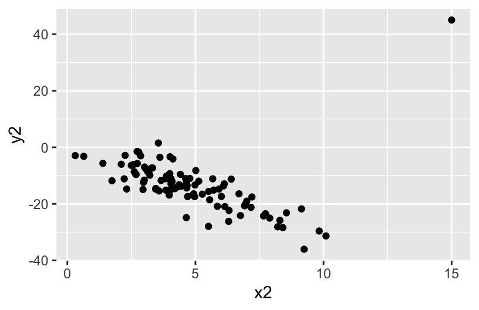

```r
# scatterplot
dat_new2 %>%
  ggplot(aes(x2, y2)) +
  geom_point()
```

```r
# correlation
dat_new2 %>% summarize(cor(x2, y2))
##   cor(x2, y2)
## 1  -0.2924792
```

The correlation changes quite a bit with the addition of this new point! Something to note is that this new point does not follow the rough linear trend that the original points had, that the first point we considered adding also had. This line seems way off base, comparatively!

1. The takeaway message here is that even though both of these additional points might be considered “outliers” because they have extreme x values, one changes the relationship between x and y much more than the other. In this case, the second point we considered would be **influential** because it changes the observed relationship between all x’s and y’s much more than the first point we considered. Not all “outliers” are considered equal!

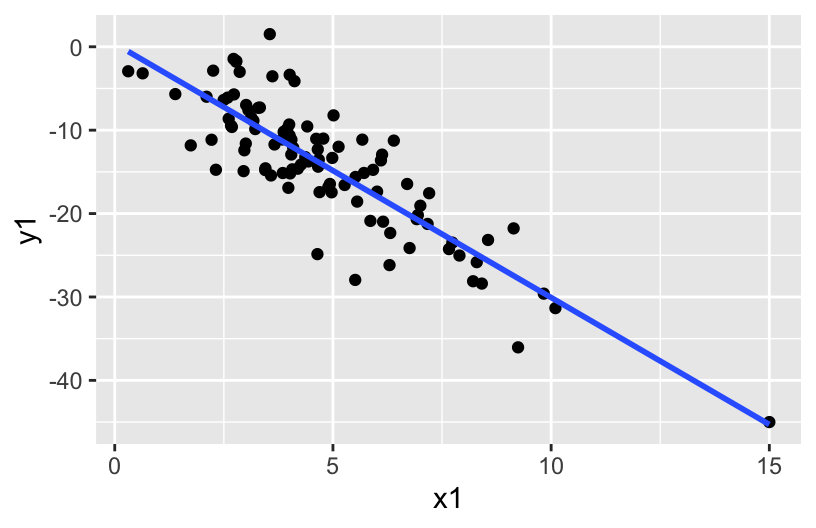

```r
dat_new1 %>%
  ggplot(aes(x1, y1)) +
  geom_point() +
  geom_smooth(method = "lm", se = FALSE)
```

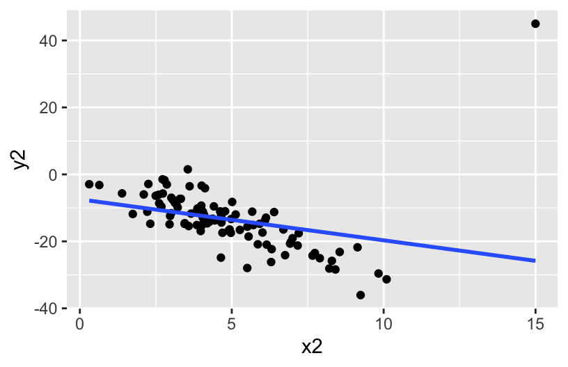

```r
dat_new2 %>%
  ggplot(aes(x2, y2)) +
  geom_point() +
  geom_smooth(method = "lm", se = FALSE)
```